# Tobacco Use and Parental Monitoring among American Indian Youth

Author

Xiaoqi Ma, Avery Turner, Audrey Sileci, & Tracy Zehner

# Abstract

American Indians (AI) and Alaska Natives (AN) report greater cigarette use than all other racial and ethnic groups and subgroups in the U.S. (Martell, Garrett, and Caraballo 2016). Tobacco use is a major cause of cardiovascular disease and lung cancer (Centers for Disease Control and Prevention 2022), both of which are leading causes of death among people who identify as American Indian (Centers for Disease Control and Prevention 2022). While past research posits that high rates of tobacco use in AI and AN youth may be due to culturally traditional use and tobacco companies targeting marginalized groups (Food and Administration 2023), less is known about how parental monitoring contributes to tobacco use. The purpose of this study was to examine if AI youth have lower reported parental monitoring compared to non-AI youth and the extent to which parental monitoring predicted ever smoking cigarettes. We hypothesized that higher reported parental monitoring would be related to lower tobacco usage rates, on average, in a population of AI and AN adolescents. Data came from the publicly available Substance Use Among American Indian Youth dataset (N = 847, 47% female). We found that AI youth had less parental monitoring compared to non-AI peers, and parental monitoring significantly predicted having ever smoked cigarettes. Findings suggest that parental monitoring is a protective factor for AI youth and it may help decrease tobacco usage in this population of youth.

# Introduction

People who identify as American Indian (AI) or Alaska Native (AN) report greater cigarette use than all other racial and ethnic groups and subgroups in the U.S. (Martell, Garrett, and Caraballo 2016). In 2022, middle and high-school students who identified as AI/AN were also more likely to report ever having used a tobacco product compared to all other racial/ethnic groups (13.5% of AI/AN compared to 13% who identified as multiracial, 12.4% who identified as White, 11.5% who identified as Black, 11.1% who identified as Hispanic/Latinx, and 3.1% who identified as Asian; (Park-Lee et al. 2022)). Nine out of ten U.S. smokers who report smoking at least daily tried their first cigarette before the age of 18 (Center for Disease Control and [CDC] 2022). Tobacco use can cause cardiovascular disease and lung cancer which, respectively, are the leading causes of death and cancer deaths among people who identify as AI (Centers for Disease Control and Prevention 2022). Identifying risk and protective factors of tobacco use among AI youth is a top priority given the racial disparity in youth smoking rates and the substantial health burden caused by tobacco use in this community.

Parental monitoring – parenting behaviors including attention to where children go and activities they engage in (Dishion and McMahon 1998) – may be a protective factor for decreased substance use among AI youth (Boyd-Ball et al. 2014; Haruyama et al. 2023; Schick et al. 2022). Limited research has been conducted that examines this relation with a focus on tobacco use among AI youth. The challenges that AI parents face are unique. Specifically, traditional AI parenting practices were disrupted by colonization that led to children being separated from their families by forcibly attending boarding schools or being placed with White families, which has left a lasting impact on parental self-efficacy among AI parents (Brave Heart 1999; Walters et al. 2011). Several support services and interventions are available that target parental monitoring (e.g., Dishion, Nelson, and Kavanagh 2003), and increasing evidence of parental monitoring and tobacco use among AI youth contributes to the understanding of the potential of these programs in this population.

## The Present Study

Our research questions were the following:

1. Do AI students report less parental monitoring compared to non-AI students? We hypothesized that AI students would report less parental monitoring compared to non-AI students.
2. Do AI students with higher reported parental monitoring use substances at lower rates? We hypothesized that AI students with higher reported parental monitoring do use substances at lower rates compared to non-AI students.

# Methods

## Participants

Data came from the Substance Use Among American Indian Youth (2015-2020) data set (Swaim and Stanley 2021). Participants were adolescents in grades 7 and above attending school on or near (within 25 miles of) AI reservations or designated tribal lands across the U.S. Students were recruited through letters sent home to parents and through posts on local media sites.

To identify participating schools, the following data sets were used: the NCES Common Core of Data (CCD), the NCES Private School Universe Survey (PPS), and the Bureau of Indian Education (BIE) National Directory. Only schools with at least 20% AI enrollment and total enrollment of at least 20 students were eligible, and eligible schools were randomly selected to participate.

## Procedure

Participants completed the anonymous *Our Youth, Our Future* (OYOF) online survey using Qualtrics, an online survey software (Qualtrics 2020). School staff was present, but remained in an area where student responses were not visible. Staff read survey directions and informed students that they could decline to participate or leave blank any questions they did not wish to answer. These instructions were also included in the online survey.

## Variables of Interest

For our first research question, we used self-reported AI identity of 15-year-old youth (not mutually exclusive with other races) as a predictor of parental monitoring level. For our second research question, we used parental monitoring level as a predictor of having ever smoked cigarettes for 15-year-old participants.

We used a subset of the data to only analyze data of 15-year-old participants, because we suspected that parental monitoring was a stronger influence on child health outcomes when the youth still lived at home and did not have a driver’s license. This age is within typical age range to initiate tobacco use in this population of AI youth.

Parental monitoring is a constructed variable comprised of nine items from the OYOF survey regarding parental knowledge of their adolescent’s activities and engagement in monitoring behaviors (e.g., *My parents ask about happenings at school*; *I need permission to be out late on weekends*). One item was reverse coded (i.e., *I keep secrets from my parents about what I do in my free time*). Parental monitoring level is the sum score of the nine items, which ranged from 9-45. In other words, higher sum scores indicate a higher level of parental monitoring for participants.

The ever smoked variable was dichotomized for analysis. Participants answered one question about having ever smoked cigarettes. We chose to dichotomize this variable since participants in this subset were on the low end of the typical age range to initiate tobacco use.

## Analytic Approach

To answer the first research question, we ran a two-sample t-test on parental monitoring between AI and non-AI 15-year-old youths. To answer the second research question, we used a logistic regression to examine the relation between parental monitoring and having ever smoked cigarettes. All analyses were completed using R Version 2023.03.1+446 (R Core Team 2023). The packages used for analysis were Tidyverse (Wickham et al. 2019), here (Müller 2020), rio (Chan et al. 2018), ggplot2 (Wickham 2016), modelsummary (Arel-Bundock 2022), janitor (Firke 2023), gtsummary (Sjoberg et al. 2021), forcats (Wickham 2023), and sandwich (Zeileis, Köll, and Graham 2020).

# Results

## Descriptive Statistics

**Table 1. Descriptive Statistics**

| **Characteristic** | **N = 847**<sup>1</sup> |
| --- | --- |
| Sex |  |
| Male | 53% |
| Female | 47% |
| Ever Smoked | 27% |
| AI | 66% |
| Parental Monitoring | 32 (25, 39) |

<sup>1</sup> %; Median (IQR)

Of the 15-year-old participants in this sample (N= 847), 26.918536% reported ever having smoked a cigarette. The majority of students in this sample self-identified as AI (65.9976387%). Most students self-reported relatively high levels of parental monitoring (M= 30.9563164) on the parental monitoring scale, which ranged in possible values from 9-45, with higher scores indicating more monitoring. 52.6564345% of our sample identified as male and 47.3435655% identified as female, indicating a relatively equal distribution of participants by sex.

## AI Students and Parental Monitoring

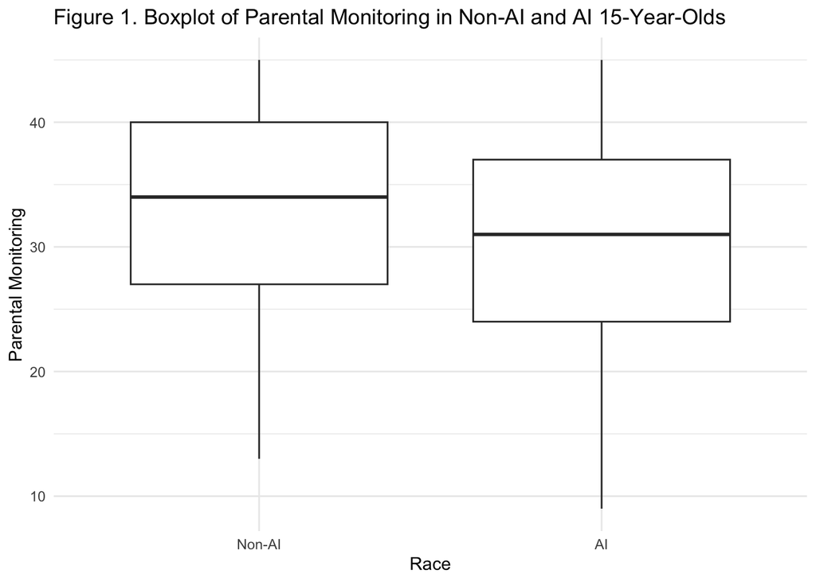

The independent two-sample t-test on parental monitoring between AI and non-AI 15-year-old participants showed that AI participants reported significantly lower parental monitoring than non-AI participants (M1= 30.111, M2= 32.597, 3.808, df= 583.0281809, *p* < .001). Figure 1 showed that AI 15-year-old participants had lower average parental monitoring than non-AI 15-year-old participants.

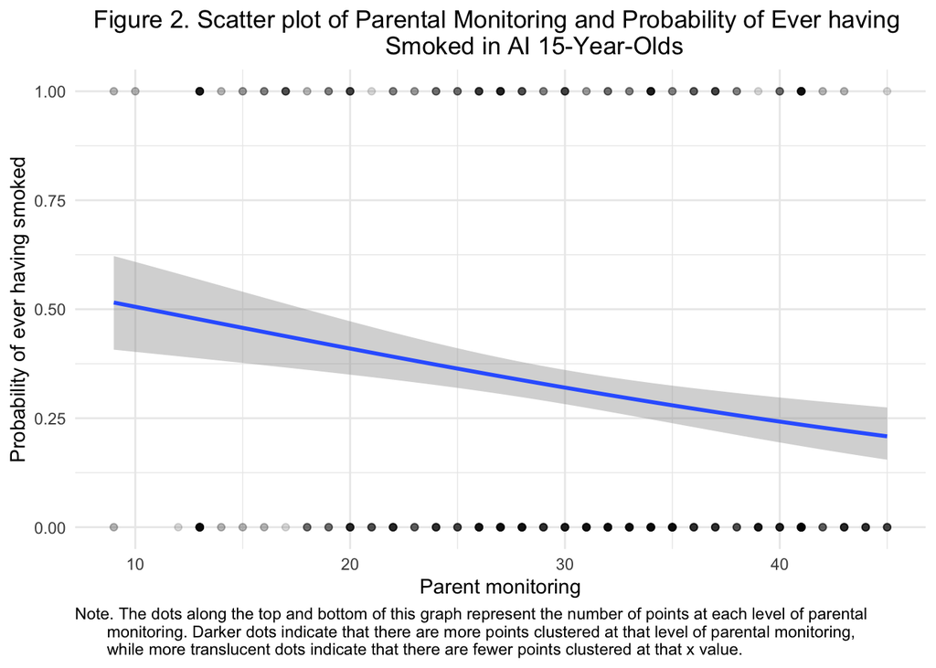

# Discussion

We found that AI youth tended to self-report less parental monitoring than their non-AI peers and that increased parental monitoring was associated with lower odds of initiating tobacco use among AI youth. There are a number of reasons why AI youth may report less parental monitoring than their non-AI peers. The historical displacement and discrimination towards people who identify as AI may increase the stressors experienced by AI parents Walters et al. (2011), limiting the amount of time that they have to dedicate to monitoring their child’s activities. Our finding that youth-reported parental monitoring was associated with decreased odds of tobacco use initiation indicates that parental monitoring may serve as a protective factor against tobacco use among AI youth. Because rates of tobacco use are high among this population (Martell, Garrett, and Caraballo 2016), identifying and promoting protective factors is key to mitigating the tobacco-related morbidity and mortality that has disproportionately affected this population.

The current analysis has the advantage of using a national dataset with a relatively large sample size. However, this study also includes limitations. Specifically, we only included 15-year-old participants in our analyses to eliminate the mediating effect of age on the relation between parental monitoring and tobacco use. Future research should include more ages in analyses. Also, because only AI youth who lived within 25 miles of a reservation were recruited to participate in this study, this analysis does not generalize to the entirety of the AI population in the U.S. Moreover, our measure of parental monitoring was reported by youth and may not fully or accurately reflect their parents’ monitoring, since youth may not be aware of all the ways that their parent monitors their behavior. Because parental monitoring was summed, this analysis is not sensitive to the different impact that certain types of monitoring may have relative to others (i.e., all questions pertaining to monitoring were given equal weight and no analyses were conducted to assess which types of monitoring most accurately predict tobacco initiation). Finally, this analysis did not measure levels of tobacco use, because smoking was coded dichotomously, so we cannot make claims about the effect of parental monitoring on the frequency or quantity of tobacco use in AI youth.

## References

Arel-Bundock, Vincent. 2022. “modelsummary: Data and Model Summaries in R.” *Journal of Statistical Software* 103 (1): 1–23. https://doi.org/10.18637/jss.v103.i01.

Boyd-Ball, Alison J., Marie-Hélène Véronneau, Thomas J. Dishion, and Kate Kavanagh. 2014. “Monitoring and Peer Influences as Predictors of Increases in Alcohol Use Among American Indian Youth.” *Prevention Science* 15 (4): 526–35. https://doi.org/10.1007/s11121-013-0399-1.

Brave Heart, Maria Yellow Horse. 1999. “Oyate Ptayela: Rebuilding the Lakota Nation Through Addressing Historical Trauma Among Lakota Parents.” In, edited by Hilary N. Weaver, 127–44. New York: Haworth Press.

Chan, Chung-Hong, Geoffrey C H Chan, Thomas J Leeper, and Jason Becker. 2018. “Rio: A Swiss-Army Knife for Data File I/O.”

Disease Control, Center for, and Prevention [CDC]. 2022. “Youth and Tobacco Use, 2022.” https://doi.org/https://www.cdc.gov/tobacco/data_statistics/fact_sheets/youth_data/tobacco_use/index.htm.

Disease Control, Centers for, and Prevention. 2022. “Smoking & Tobacco Use: American Indian and Alaska Native People Experience a Health Burden from Commercial Tobacco.” https://www.cdc.gov/tobacco/health-equity/aian/health-burden.html.

Dishion, Thomas J., and Robert J. McMahon. 1998. “Parental Monitoring and the Prevention of Child and Adolescent Problem Behavior: A Conceptual and Empirical Formulation.” *Clinical Child and Family Psychology Review* 1 (1): 61–75. https://doi.org/10.1023/A:1021800432380.

Dishion, Thomas J., Sarah E. Nelson, and Kathryn Kavanagh. 2003. “The Family Check-Up with High-Risk Young Adolescents: Preventing Early-Onset Substance Use by Parent Monitoring.” *Behavior Therapy* 34 (4): 553–71. https://doi.org/10.1016/S0005-7894(03)80035-7.

Firke, Sam. 2023. *Janitor: Simple Tools for Examining and Cleaning Dirty Data*. https://CRAN.R-project.org/package=janitor.

Food, and Drug Administration. 2023. “Commercial Tobacco Use in American Indian and Alaska Native Populations.” https://www.fda.gov/consumers/minority-health-and-health-equity-resources/commercial-tobacco-use-american-indian-and-alaska-native-populations.

Haruyama, Dorothy, Mark A. Prince, Randall C. Swaim, and Ernest L. Chavez. 2023. “The Relationship Between Depressed Affect, Parental Monitoring, and Sex on Cannabis Use Among American Indian Youth.” *The American Journal on Addictions* 32 (4): 402–9. https://doi.org/10.1111/ajad.13416.

Martell, Brandi N., Bridgette E. Garrett, and Ralph S. Caraballo. 2016. “Disparities in Adult Cigarette Smoking United States, 20022005 and 20102013.” *MMWR. Morbidity and Mortality Weekly Report* 65 (30): 753–58. https://doi.org/10.15585/mmwr.mm6530a1.

Müller, Kirill. 2020. *Here: A Simpler Way to Find Your Files*. https://CRAN.R-project.org/package=here.

Park-Lee, Eunice, Chunfeng Ren, Maria Cooper, Monica Cornelius, Ahmed Jamal, and Karen A. Cullen. 2022. “Tobacco Product Use Among Middle and High School Students United States, 2022.” *MMWR. Morbidity and Mortality Weekly Report* 71 (45): 1429–35. https://doi.org/10.15585/mmwr.mm7145a1.

Qualtrics. 2020. “Qualtrics.” https://www.qualtrics.com.

R Core Team. 2023. *R: A Language and Environment for Statistical Computing*. Vienna, Austria: R Foundation for Statistical Computing. https://www.R-project.org/.

Schick, Melissa R., Tessa Nalven, Emmanuel D. Thomas, Nicole H. Weiss, and Nichea S. Spillane. 2022. “Depression and Alcohol Use in American Indian Adolescents: The Influence of Family Factors.” *Alcoholism: Clinical and Experimental Research* 46 (1): 141–51. https://doi.org/10.1111/acer.14748.

Sjoberg, Daniel D., Karissa Whiting, Michael Curry, Jessica A. Lavery, and Joseph Larmarange. 2021. “Reproducible Summary Tables with the Gtsummary Package.” *The R Journal* 13: 570–80. https://doi.org/10.32614/RJ-2021-053.

Swaim, Randall C., and Linda R. Stanley. 2021. “Substance Use Among American Indian Youth: Epidemiology and Etiology, [United States], 2015-2020.” Inter-university Consortium for Political; Social Research. https://doi.org/10.3886/ICPSR37997.v1.

Walters, Karina L., Selina A. Mohammed, Teresa Evans-Campbell, Ramona E. Beltrán, David H. Chae, and Bonnie Duran. 2011. “Bodies Don’t Just Tell Stories, They Tell Histories: Embodiment of Historical Trauma Among American Indians and Alaska Natives.” *Du Bois Review: Social Science Research on Race* 8 (1): 179–89. https://doi.org/10.1017/S1742058X1100018X.

Wickham, Hadley. 2016. *Ggplot2: Elegant Graphics for Data Analysis*. Springer-Verlag New York. https://ggplot2.tidyverse.org.

———. 2023. *Forcats: Tools for Working with Categorical Variables (Factors)*. https://forcats.tidyverse.org/.

Wickham, Hadley, Mara Averick, Jennifer Bryan, Winston Chang, Lucy D’Agostino McGowan, Romain François, Garrett Grolemund, et al. 2019. “Welcome to the tidyverse.” *Journal of Open Source Software* 4 (43): 1686. https://doi.org/10.21105/joss.01686.

Zeileis, Achim, Susanne Köll, and Nathaniel Graham. 2020. “Various Versatile Variances: An Object-Oriented Implementation of Clustered Covariances in R.” *Journal of Statistical Software* 95 (1): 1–36. https://doi.org/10.18637/jss.v095.i01.